# Retail_Analysis

## Analysis of Online Retail Operations

This document focuses on analyzing customer behavior and optimizing inventory management for an online retail platform. Through detailed data analysis, we aim to enhance customer satisfaction and operational efficiency by addressing the following areas:

1. **Customer Segmentation**: This section aims to identify different customer segments based on their ordering behavior, such as frequency, time of day, and days since the prior order. Understanding customer preferences allows for the development of tailored marketing strategies.
2. **Inventory Management**: We will develop a predictive model to estimate optimal inventory levels for products across various departments and aisles. This model considers factors like the day of the week and hour of the day to optimize stock levels and reduce waste.
3. **Order Fulfillment**: This part investigates ways to optimize the order fulfillment process. By analyzing when orders are placed, we strategize on improving delivery efficiency and reducing operational costs.
4. **Future Recommendations**: We outline further actions and methodologies that could be employed to extend the insights and enhance the models developed, given additional time and resources.

### Datasets Overview

The datasets provide a comprehensive view of the operations within an online retail platform, reflecting the dynamics of modern shopping. Customers select products from a wide range of categories, facilitated by a well-organized virtual store layout. The `orders` dataset details the checkout process, `order_products` shows the specific items purchased, the `products` dataset lists available items, and the `aisles` and `departments` datasets offer insight into the store's organizational structure.

**Aisles**: Contains 134 rows and 2 columns, detailing unique identifiers for different aisles.

```python
import pandas as pd

aisles = pd.read_csv('./aisles.csv')
print(aisles.shape)
aisles
```

```
(134, 2)
```

|  | aisle_id | aisle |
| --- | --- | --- |
| 0 | 1 | prepared soups salads |
| 1 | 2 | specialty cheeses |
| 2 | 3 | energy granola bars |
| 3 | 4 | instant foods |
| 4 | 5 | marinades meat preparation |
| ... | ... | ... |
| 129 | 130 | hot cereal pancake mixes |
| 130 | 131 | dry pasta |
| 131 | 132 | beauty |
| 132 | 133 | muscles joints pain relief |
| 133 | 134 | specialty wines champagnes |

134 rows × 2 columns

**Departments**: Has 21 rows and 2 columns, with unique identifier and the name of department.

```python
dept = pd.read_csv('./departments.csv')
print(dept.shape)
dept
```

```
(21, 2)
```

|  | department_id | department |
| --- | --- | --- |
| 0 | 1 | frozen |
| 1 | 2 | other |
| 2 | 3 | bakery |
| 3 | 4 | produce |
| 4 | 5 | alcohol |
| 5 | 6 | international |
| 6 | 7 | beverages |
| 7 | 8 | pets |
| 8 | 9 | dry goods pasta |
| 9 | 10 | bulk |
| 10 | 11 | personal care |
| 11 | 12 | meat seafood |
| 12 | 13 | pantry |
| 13 | 14 | breakfast |
| 14 | 15 | canned goods |
| 15 | 16 | dairy eggs |
| 16 | 17 | household |
| 17 | 18 | babies |
| 18 | 19 | snacks |
| 19 | 20 | deli |
| 20 | 21 | missing |

**Products**: Includes 49,688 rows and 4 columns, providing information on various products.

- product_id: A unique identifier for each product.
- product_name: The name of the product.
- aisle_id: The identifier for the aisle.
- department_id: The identifier for the department that the product belongs to.

```python
products = pd.read_csv('./products.csv')
print(products.shape)
products
```

```
(49688, 4)
```

|  | product_id | product_name | aisle_id | department_id |
| --- | --- | --- | --- | --- |
| 0 | 1 | Chocolate Sandwich Cookies | 61 | 19 |
| 1 | 2 | All-Seasons Salt | 104 | 13 |
| 2 | 3 | Robust Golden Unsweetened Oolong Tea | 94 | 7 |
| 3 | 4 | Smart Ones Classic Favorites Mini Rigatoni Wit... | 38 | 1 |
| 4 | 5 | Green Chile Anytime Sauce | 5 | 13 |
| ... | ... | ... | ... | ... |
| 49683 | 49684 | Vodka, Triple Distilled, Twist of Vanilla | 124 | 5 |
| 49684 | 49685 | En Croute Roast Hazelnut Cranberry | 42 | 1 |
| 49685 | 49686 | Artisan Baguette | 112 | 3 |
| 49686 | 49687 | Smartblend Healthy Metabolism Dry Cat Food | 41 | 8 |
| 49687 | 49688 | Fresh Foaming Cleanser | 73 | 11 |

49688 rows × 4 columns

**Orders**: dataset with 3,346,083 rows and 7 columns, detailing individual orders.

- order_id: A unique identifier for each order.
- user_id: A unique identifier for the user who placed the order.
- eval_set: The category of the dataset.
- order_number: The order sequence number for a user (1st, 2nd, etc.).
- order_dow: The day of the week the order was placed.
- order_hour_of_day: The hour of the day the order was placed.
- days_since_prior_order: The number of days since the user's previous order.

```python
orders = pd.read_csv('./orders.csv')
print(orders.shape)
orders['first_order'] = orders['days_since_prior_order'].apply(lambda x: 1 if pd.isnull(x) else 0)
orders
```

```
(3346083, 7)
```

|  | order_id | user_id | eval_set | order_number | order_dow | order_hour_of_day | days_since_prior_order | first_order |
| --- | --- | --- | --- | --- | --- | --- | --- | --- |
| 0 | 2539329 | 1 | prior | 1 | 2 | 8 | NaN | 1 |
| 1 | 2398795 | 1 | prior | 2 | 3 | 7 | 15.0 | 0 |
| 2 | 473747 | 1 | prior | 3 | 3 | 12 | 21.0 | 0 |
| 3 | 2254736 | 1 | prior | 4 | 4 | 7 | 29.0 | 0 |
| 4 | 431534 | 1 | prior | 5 | 4 | 15 | 28.0 | 0 |
| ... | ... | ... | ... | ... | ... | ... | ... | ... |
| 3346078 | 2266710 | 206209 | prior | 10 | 5 | 18 | 29.0 | 0 |
| 3346079 | 1854736 | 206209 | prior | 11 | 4 | 10 | 30.0 | 0 |
| 3346080 | 626363 | 206209 | prior | 12 | 1 | 12 | 18.0 | 0 |
| 3346081 | 2977660 | 206209 | prior | 13 | 1 | 12 | 7.0 | 0 |
| 3346082 | 272231 | 206209 | train | 14 | 6 | 14 | 30.0 | 0 |

3346083 rows × 8 columns

A new column `first_order` has been added to indicate first-time purchases. The determination of the first purchase is based on the absence of data in the `days_since_prior_order` column. It is set to `1` when is missing, and `0` otherwise, enabling quick identification of new customers.

```python
unique_customers = orders['user_id'].nunique()
print(f'Total number of unique customers: {unique_customers}')
```

```
Total number of unique customers: 206209
```

#### Outlier analysis (boxplot)

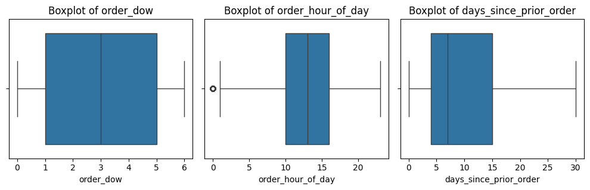

```python
import seaborn as sns
import matplotlib.pyplot as plt

cols = ['order_dow', 'order_hour_of_day', 'days_since_prior_order']
plt.figure(figsize=(10, 3.3))
for i, col in enumerate(cols):
    plt.subplot(1, 3, i+1)
    sns.boxplot(x=orders[col])
    plt.title(f'Boxplot of {col}')
plt.tight_layout()
plt.show()
```

#### Data Preparation

To create a comprehensive dataset that links customers with their orders and the products purchased, I'll combine the data from `orders`, `order_products`, `products`, `aisles`, and `departments` tables. This process typically involves merging the `orders` and `order_products` tables by `order_id`, and then joining the resulting table with `products`, `aisles`, and `departments` using the respective `product`, `aisle`, and `department` IDs.

```python
ord_prod = pd.read_csv('./order_products.csv')

merged_df = pd.merge(orders, ord_prod, on='order_id', how='left')
merged_df = pd.merge(merged_df, products, on='product_id', how='left')
merged_df = pd.merge(merged_df, aisles, on='aisle_id', how='left')
merged_df = pd.merge(merged_df, dept, on='department_id', how='left')
merged_df.head()
```

|  | order_id | user_id | eval_set | order_number | order_dow | order_hour_of_day | days_since_prior_order | first_order | product_id | add_to_cart_order | reordered | product_name | aisle_id | department_id | aisle | department |
| --- | --- | --- | --- | --- | --- | --- | --- | --- | --- | --- | --- | --- | --- | --- | --- | --- |
| 0 | 2539329 | 1 | prior | 1 | 2 | 8 | NaN | 1 | 196 | 1 | 0 | Soda | 77 | 7 | soft drinks | beverages |
| 1 | 2539329 | 1 | prior | 1 | 2 | 8 | NaN | 1 | 14084 | 2 | 0 | Organic Unsweetened Vanilla Almond Milk | 91 | 16 | soy lactosefree | dairy eggs |
| 2 | 2539329 | 1 | prior | 1 | 2 | 8 | NaN | 1 | 12427 | 3 | 0 | Original Beef Jerky | 23 | 19 | popcorn jerky | snacks |
| 3 | 2539329 | 1 | prior | 1 | 2 | 8 | NaN | 1 | 26088 | 4 | 0 | Aged White Cheddar Popcorn | 23 | 19 | popcorn jerky | snacks |
| 4 | 2539329 | 1 | prior | 1 | 2 | 8 | NaN | 1 | 26405 | 5 | 0 | XL Pick-A-Size Paper Towel Rolls | 54 | 17 | paper goods | household |

### 1. **Customer Segmentation**

#### 1.1 *Orders*

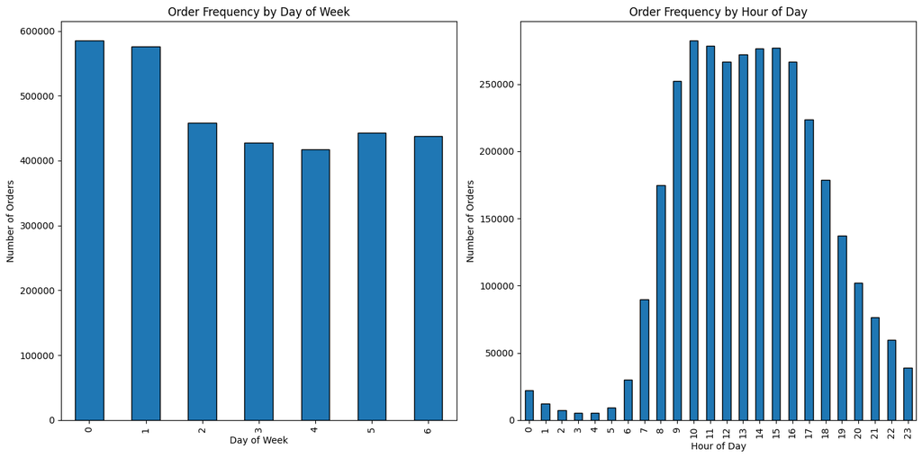

```python
# Calculate the frequency of orders by day of the week
order_dow_counts = orders['order_dow'].value_counts().sort_index()

# Calculate the frequency of orders by hour of the day
order_hour_counts = orders['order_hour_of_day'].value_counts().sort_index()

# Plot por dia da semana
plt.figure(figsize=(14, 7))
plt.subplot(1, 2, 1)
order_dow_counts.plot(kind='bar', edgecolor='black')  # Adicionando color e edgecolor
plt.title('Order Frequency by Day of Week')
plt.xlabel('Day of Week')
plt.ylabel('Number of Orders')

# Plot por hora do dia
plt.subplot(1, 2, 2)
order_hour_counts.plot(kind='bar', edgecolor='black')  # Adicionando color e edgecolor
plt.title('Order Frequency by Hour of Day')
plt.xlabel('Hour of Day')
plt.ylabel('Number of Orders')

plt.tight_layout()
plt.show()
```

The histogram for the day of the week (`order_dow`) shows that orders are fairly evenly distributed throughout the week, with the highest number of orders occurring on day 0 and 1, which could correspond to the weekend or the beginning of the week, depending on the dataset's encoding.

The histogram for the hour of the day (`order_hour_of_day`) indicates that order frequency is highest between 10 AM and 4 PM, with a peak around 10 AM to 11 AM, and it significantly drops off during the late night and early morning hours, from midnight to 6 AM.

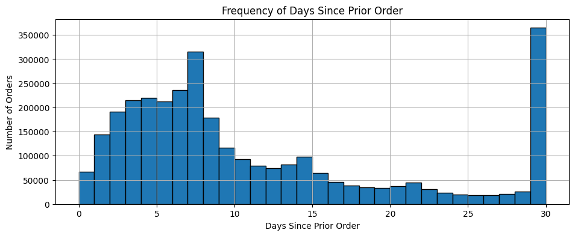

```python
# Plot of days since prior order
plt.figure(figsize=(11, 4))
orders['days_since_prior_order'].hist(bins=30, edgecolor='black')
plt.title('Frequency of Days Since Prior Order')
plt.xlabel('Days Since Prior Order')
plt.ylabel('Number of Orders')
plt.show()
```

The frequency of orders tends to be higher with fewer days since the prior order, indicating that many customers place orders in quick succession. There is a noticeable peak at 7 days, suggesting a weekly ordering pattern. Additionally, there's an even larger peak at 30 days, which indicates a monthly restocking behavior.

#### Optimized Marketing Strategies (Orders)

By aligning marketing strategies with customer behavior patterns, businesses can increase engagement, improve customer satisfaction, and drive sales. Understanding customer preferences from the order patterns, we can optimize strategies in the following ways:

1. **Time-based Promotions**: Since orders peak around 10 AM to 4 PM, offer limited-time promotions during these hours to boost sales further.
2. **Weekend Focus**: With higher order volumes on days 0 and 1, focus marketing efforts and special deals on these days to capitalize on increased traffic.
3. **Personalized Email Campaigns**: Send out email campaigns just before the peak ordering times, especially on the busiest days, to remind customers of deals and promotions.
4. **Targeted Ads**: Use targeted advertising during peak days and hours to reach customers when they are most likely to shop.
5. **Night Owl Specials**: To increase orders during off-peak hours, offer special discounts for orders placed late at night or early in the morning.

#### 1.2 *Customers*

```python
# Feature Engineering
# Total de Pedidos por Cliente
customer_order_count = merged_df.groupby('user_id')['order_id'].nunique()

# Frequência de Compra
customer_freq = merged_df.groupby('user_id').size() / merged_df.groupby('user_id')['days_since_prior_order'].sum()

# Variedade de Produtos
customer_product_variety = merged_df.groupby('user_id')['product_id'].nunique()

# Categorias Principais
#customer_top_department = merged_df.groupby(['user_id', 'department'])['department'].count().sort_values(ascending=False).groupby(level=0).head(1).reset_index(level=1)

# Dias Desde o Último Pedido
customer_days_since_last_order = merged_df.groupby('user_id')['days_since_prior_order'].last()

# Preparar DataFrame para segmenta\u00e7\u00e3o
customer_features = pd.DataFrame({'total_orders': customer_order_count,
                                 'purchase_frequency': customer_freq,
                                 'product_variety': customer_product_variety,
                                 'days_since_last_order': customer_days_since_last_order}).reset_index()
                                 #'top_department': customer_top_department['department']}).reset_index()

customer_features.head()
```

|  | user_id | total_orders | purchase_frequency | product_variety | days_since_last_order |
| --- | --- | --- | --- | --- | --- |
| 0 | 1 | 11 | 0.056090 | 19 | 14.0 |
| 1 | 2 | 15 | 0.058916 | 121 | 30.0 |
| 2 | 3 | 12 | 0.098214 | 33 | 15.0 |
| 3 | 4 | 5 | 0.083721 | 17 | 0.0 |
| 4 | 5 | 5 | 0.106729 | 28 | 6.0 |

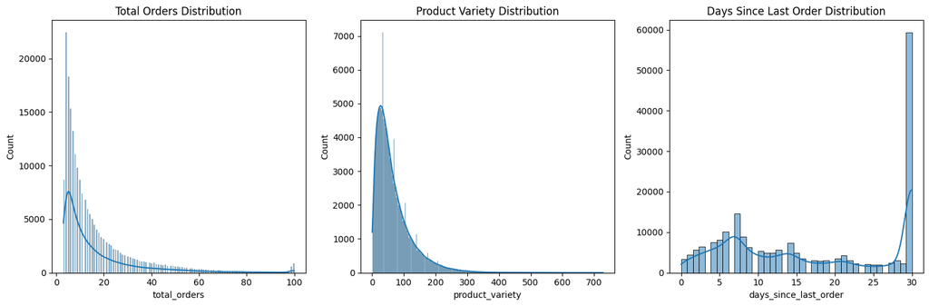

```python
# Histograms for each feature
plt.figure(figsize=(15, 5))

# Total Orders
plt.subplot(1, 3, 1)
sns.histplot(customer_features['total_orders'], kde=True)
plt.title('Total Orders Distribution')

# Product Variety
plt.subplot(1, 3, 2)
sns.histplot(customer_features['product_variety'], kde=True)
plt.title('Product Variety Distribution')

# Days Since Last Order
plt.subplot(1, 3, 3)
sns.histplot(customer_features['days_since_last_order'], kde=True)
plt.title('Days Since Last Order Distribution')

plt.tight_layout()
plt.show()
```

```python
import numpy as np
from sklearn.preprocessing import StandardScaler
from sklearn.cluster import KMeans

# Check for infinite or NaN values and replace them
customer_features.replace([np.inf, -np.inf], np.nan, inplace=True)
customer_features.dropna(inplace=True)

# Standardize the features
scaler = StandardScaler()
customer_features_scaled = scaler.fit_transform(customer_features[['total_orders', 'purchase_frequency', 'product_variety', 'days_since_last_order']])

# Determine the optimal number of clusters using the elbow method
inertia = []
for k in range(1, 11):
    kmeans = KMeans(n_clusters=k, random_state=333)
    kmeans.fit(customer_features_scaled)
    inertia.append(kmeans.inertia_)
```

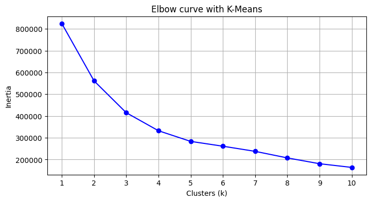

```python
k_values = range(1, 11)

# Plotando a curva do cotovelo
plt.figure(figsize=(8, 4))
plt.plot(k_values, inertia, 'bo-')
plt.xlabel('Clusters (k)')
plt.ylabel('Inertia')
plt.title('Elbow curve with K-Means')
plt.xticks(k_values)
plt.grid(True)
plt.show()
```

Selecting **4** clusters is likely to be the most efficient choice, providing a balance between minimizing within-cluster variance and avoiding overfitting with too many clusters. To determine the appropriate number of clusters from the provided inertia values (sum of squared distances of samples to their closest cluster center), we look for the point where the elbow curve becomes less steep, indicating that adding more clusters does not result in a significant improvement in the compactness of the clusters.

```
   user_id  total_orders  purchase_frequency  product_variety  \
0        1            11            0.056090               19
1        2            15            0.058916              121
2        3            12            0.098214               33
3        4             5            0.083721               17
4        5             5            0.106729               28

   days_since_last_order  cluster
0                   14.0        0
1                   30.0        1
2                   15.0        0
3                    0.0        0
4                    6.0        0
```

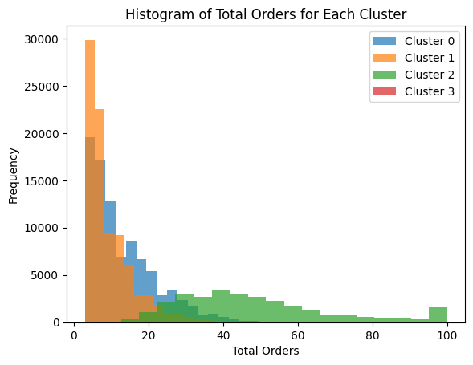

```python
# Apply KMeans with 4 clusters
kmeans = KMeans(n_clusters=4, random_state=333)
kmeans.fit(customer_features_scaled)

# Create a new column in the dataframe with the cluster assignment
customer_features['cluster'] = kmeans.labels_

# Display the first few rows of the dataframe with the cluster assignment
print(customer_features.head())
customer_features['cluster'].value_counts(normalize=True)*100

#for i in range(4):
#    cluster_data = customer_features[customer_features['cluster'] == i]
#    sns.pairplot(cluster_data, vars=['total_orders', 'purchase_frequency', 'product_variety', 'days_since_last_order'], hue='cluster', palette='viridis')
for cluster in sorted(customer_features['cluster'].unique()):
    # Filtrar os dados para o cluster atual
    cluster_data = customer_features[customer_features['cluster'] == cluster]

    # Criar o histograma usando matplotlib
    plt.hist(cluster_data['total_orders'], bins=20, alpha=0.7, label=f'Cluster {cluster}')

# Adicionar rótulos e título ao gráfico
plt.xlabel('Total Orders')
plt.ylabel('Frequency')
plt.title('Histogram of Total Orders for Each Cluster')
plt.legend()

# Mostrar o gráfico
plt.show()
```

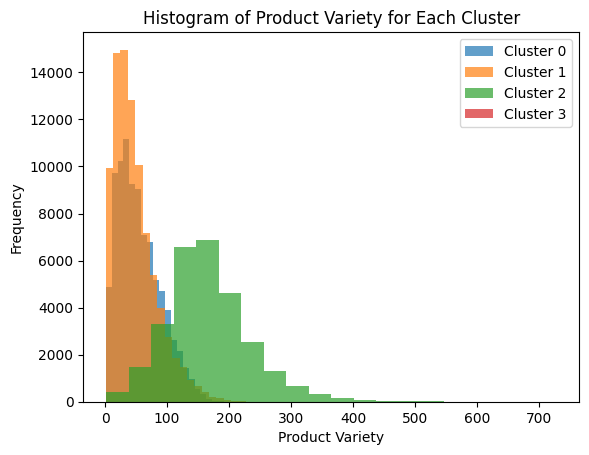

```python
for cluster in sorted(customer_features['cluster'].unique()):
    # Filtrar os dados para o cluster atual
    cluster_data = customer_features[customer_features['cluster'] == cluster]

    # Criar o histograma usando matplotlib
    plt.hist(cluster_data['product_variety'], bins=20, alpha=0.7, label=f'Cluster {cluster}')

# Adicionar rótulos e título ao gráfico
plt.xlabel('Product Variety')
plt.ylabel('Frequency')
plt.title('Histogram of Product Variety for Each Cluster')
plt.legend()
```

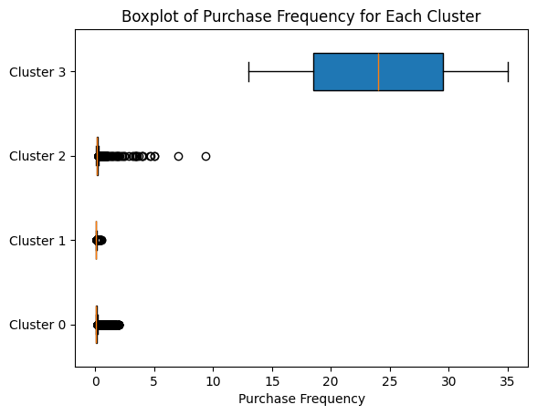

```python
# Inicialize uma figura e eixos para o boxplot
fig, ax = plt.subplots()

# Crie o boxplot para cada cluster único
ax.boxplot([customer_features[customer_features['cluster'] == cluster]['purchase_frequency'] for cluster in sorted(customer_features['cluster'].unique())],
           labels=[f'Cluster {cluster}' for cluster in sorted(customer_features['cluster'].unique())],
           vert=False, patch_artist=True)

# Adicione rótulos e título aos eixos
ax.set_xlabel('Purchase Frequency')
ax.set_title('Boxplot of Purchase Frequency for Each Cluster')

# Exiba o boxplot
plt.show()
```

#### Optimized Marketing Strategies (Customers)

For each cluster, analyze purchase patterns, preferences, and feedback to further refine these strategies. Use A/B testing to determine the most effective tactics and continuously adjust based on performance data.

### 2. **Inventory Management**

A suitable model for a predictive model that estimates inventory levels could be a Random Forest Regressor, which can handle non-linear relationships and interactions between features.

```python
from sklearn.model_selection import train_test_split
from sklearn.ensemble import RandomForestRegressor
from sklearn.metrics import mean_squared_error, r2_score

inventory_data = merged_df.groupby(['product_id', 'department_id', 'aisle_id', 'order_dow', 'order_hour_of_day']).size().reset_index(name='order_count')
inventory_data

# Split the data into features and target
X = inventory_data.drop('order_count', axis=1)
y = inventory_data['order_count']

# Split the data into training and testing sets
X_train, X_test, y_train, y_test = train_test_split(X, y, test_size=0.2, random_state=333)

# Initialize the Random Forest Regressor
model = RandomForestRegressor(n_estimators=60, random_state=333)

# Train the model
model.fit(X_train, y_train)

# Predict on the test set
y_pred = model.predict(X_test)


rmse = mean_squared_error(y_test, y_pred, squared=False)
r2 = r2_score(y_test, y_pred)

# Return the RMSE and R-squared as well
{'RMSE': rmse, 'R2': r2}
```

```
{'RMSE': 7.887598104514975, 'R2': 0.9843251903712902}
```

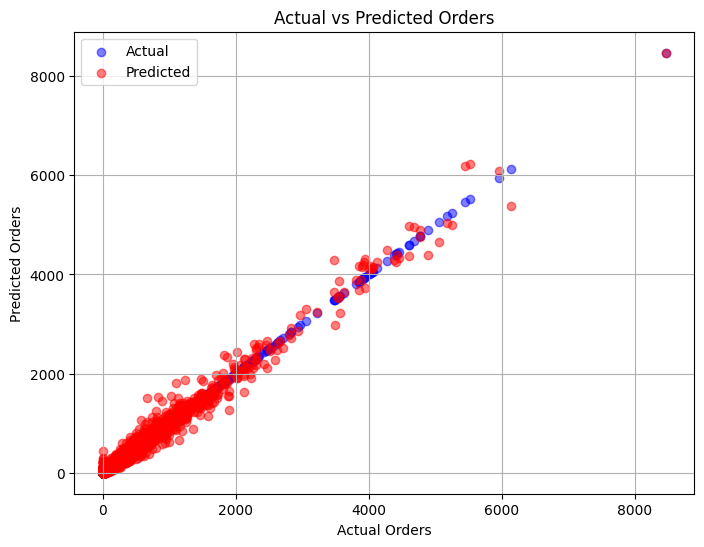

```python
# Plot actual vs predicted values
plt.figure(figsize=(8, 6))
plt.scatter(y_test, y_test, label='Actual', color='blue', alpha=0.5)
plt.scatter(y_test, y_pred, label='Predicted', color='red', alpha=0.5)
plt.title('Actual vs Predicted Orders')
plt.xlabel('Actual Orders')
plt.ylabel('Predicted Orders')
plt.legend()
plt.grid(True)
plt.show()
```

### Application of Predictive Model

The predictive model generates predictions for the number of orders, considering factors such as the day of the week and the hour of the day for products across various departments and aisles.

- **Demand Forecasting**: The model provides detailed forecasts of expected product orders, enabling precise inventory planning.
- **Safety Stock Levels**: We calculate safety stock levels to buffer against demand fluctuations, ensuring consistent product availability.
- **Replenishment Strategies**: Predictive insights guide the scheduling and quantity of inventory restocking, aligning supply with anticipated demand.
- **Shelf Life Management**: For perishable goods, the model's output informs ordering decisions to prevent spoilage and reduce waste.
- **Accuracy Monitoring**: Ongoing comparison of model forecasts with actual sales data allows for continuous refinement of our predictive capabilities.
- **Dynamic Pricing**: In cases of potential overstock, we employ dynamic pricing to encourage sales and prevent excess inventory.
- **Supply Chain Collaboration**: Sharing forecast data with suppliers ensures better production and distribution planning, enhancing overall supply chain responsiveness.

### 3. **Order Fulfillment**

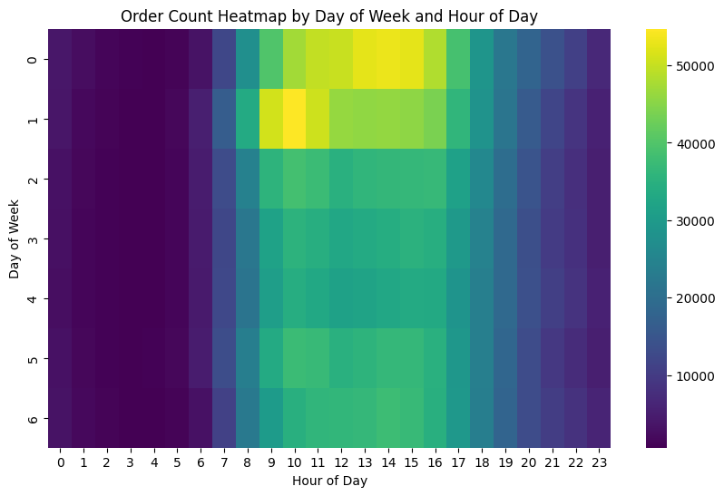

```python
# Pivot the DataFrame to prepare for heatmap
heatmap_data = dow_hour_grouped.pivot(index='order_dow', columns='order_hour_of_day', values='order_count')

# Create the heatmap
plt.figure(figsize=(10, 6))
sns.heatmap(heatmap_data, cmap='viridis', annot=False)
plt.title('Order Count Heatmap by Day of Week and Hour of Day')
plt.xlabel('Hour of Day')
plt.ylabel('Day of Week')
plt.show()
```

The heatmap visualization indicates the days of the week and times of day that have higher order volumes.

Specifically, the busiest time for orders is on day 1 of the week, during the 10 AM. During this hour, the highest number of orders was recorded, with a total of 54,719 orders. This is a critical time for staffing and resource allocation to handle the peak in order volume efficiently.

The least busy time for orders is on day 3 of the week, during the 3 AM, with the lowest number of orders recorded at 635. It may be beneficial for the business to consider strategies like incentivizing orders during these times or reducing operational costs to maintain efficiency.

### 4. **Additional Work**

Over the next two weeks, the focus will be on refining customer segmentation, enhancing inventory management, and optimizing order fulfillment. Advanced data analysis, A/B testing, and process improvements will be key. The goal is to create scalable, efficient processes that are responsive to customer needs and business growth.

1. **Customer Segmentation**
   - Refine segmentation with advanced clustering techniques.
   - Analyze customer lifetime value (CLV) for segments.
   - Gather qualitative data through surveys or focus groups.
2. **Inventory Management**
   - Develop a machine learning demand forecasting model.
   - Optimize safety stock levels for product categories.
   - Explore vendor-managed inventory (VMI) with suppliers.
3. **Order Fulfillment**
   - Analyze current fulfillment workflow for inefficiencies.
   - Pilot a warehouse management system (WMS).
   - Test different packaging options to reduce materials and time.
4. **A/B Testing**
   - Design A/B tests for targeted marketing campaigns.
   - Test inventory replenishment strategies.
   - A/B test order packing and shipping methods.
5. **Data Integration and Monitoring**
   - Combine data from sales, inventory, and customer feedback.
   - Set up real-time dashboards for KPI monitoring.
6. **Scalability**
   - Ensure systems and processes are scalable.
   - Plan for potential risks with contingency plans.